# Average Poor Mental Health Days Increase from 2019 to 2025

- Show All Code
- Hide All Code
- View Source

431 Project A using CHR data in Indiana, Kentucky, Michigan, Ohio, Pennsylvania, and West Virginia

Author

Lauren Sapienza

Modified

2025-10-28

# 1 R Packages

```r
knitr::opts_chunk$set(comment = NA)

library(janitor)
library(naniar)
library(xfun)
library(knitr)
library(patchwork)
library(rstanarm)
library(car)
library(MKinfer)

library(easystats)
library(tidyverse)
theme_set(theme_bw())

source("Love-431.R")
```

# 2 Data Ingest

First, we ingest the data into R, select the columns of interest, and filter the data to rows with `county_clustered` values of 1.

```r
chr_2025_raw <- read_csv("analytic_data2025_v2.csv", skip = 1, guess_max = 4000,
                         show_col_types = FALSE) |>
  select(fipscode, county, state, county_clustered, year, ends_with("rawvalue")) |>
  filter(county_clustered == 1)

dim(chr_2025_raw)
```

```
[1] 3089   95
```

This results in a tibble with 3089 rows and 95 columns.

# 3 State Selection

Then we filter to rows with only our states of interest (Indiana, Kentucky, Michigan, Ohio, Pennsylvania, and West Virginia) and change the state variable to a factor.

```r
chr_2025 <- chr_2025_raw |> filter(state == "OH" |
                                   state == "IN" |
                                   state == "KY" |
                                   state == "MI" |
                                   state == "PA" |
                                   state == "WV") |>
                            mutate(state = as_factor(state))

chr_2025 |> tabyl(state) |> adorn_totals(where = c("row")) |> adorn_pct_formatting()
```

```
 state   n percent
    IN  92   18.2%
    KY 120   23.8%
    MI  83   16.4%
    OH  88   17.4%
    PA  67   13.3%
    WV  55   10.9%
 Total 505  100.0%
```

Together, we have a total of 6 states and 505 clustered counties. I choose these states because they all bordered Ohio, creating a cluster of states with similar geographies to compare.

# 4 Variable Selection

Now we select all the variables for our tibble. I chose the following variables in addition to the required variables `fipscode`, `county`, `state`, and `county_clustered`:

- `v127`, premature age-adjusted mortality, as the analysis 1 outcome
- `v085`, uninsured, as the analysis 1 predictor
- `v002`, poor or fair health, as the analysis 2 outcome
- `v058`, proportion rural, as the analysis 2 predictor
- `v042`, poor mental health days, as the analysis 3 outcome

```r
chr_2025 <- chr_2025 |> select(fipscode, county, state, county_clustered, v127_rawvalue,
                               v058_rawvalue, v002_rawvalue, v085_rawvalue, v042_rawvalue)
```

The resulting tibble now has only 9 columns.

# 5 Variable Cleaning and Renaming

Then we rename the variables of interest while multiplying some values by 100 to obtain percentages for interpretation. Then we select all the variables we want in our final tibble and clean the names.

```r
chr_2025 <- chr_2025 |> mutate(pre_mort = v127_rawvalue,
                               uninsured = v085_rawvalue * 100,
                               poor_health = v002_rawvalue * 100,
                               prop_rural = v058_rawvalue * 100,
                               mental_2025 = v042_rawvalue)

chr_2025 <- chr_2025 |> select(fipscode, county, state, county_clustered, poor_health,
                               prop_rural, pre_mort, uninsured, mental_2025) |>
                        janitor::clean_names()
```

This results in the five variables described below.

| Initial Name | New Name | Role | Description | Year(s) Gathered |
| --- | --- | --- | --- | --- |
| `v127_rawvalue` | `pre_mort` | A1 outcome | Number of deaths among residents under age 75 per 100,000 population (age-adjusted) | 2020-2022 |
| `v085_rawvalue` | `uninsured` | A1 predictor | Percent of population under age 65 without health insurance | 2022 |
| `v002_rawvalue` | `poor_health` | A2 outcome | Percentage of adults reporting fair or poor health (age-adjusted) | 2022 |
| `v058_rawvalue` | `prop_rural` | A2 predictor | Percentage of population living in a census-defined rural area | 2020 |
| `v042_rawvalue` | `mental_2025` | A3 outcome | Average number of mentally unhealthy days reported in past 30 days (age-adjusted) | 2022 |

# 6 Creating the Analysis 2 Predictor

To create two categories of the `prop_rural` variable, first we find the 40th and 60th percentiles.

```r
chr_2025 |> summarise(q40 = quantile(prop_rural, c(0.4)),
                      q60 = quantile(prop_rural, c(0.6)))
```

```
# A tibble: 1 × 2
    q40   q60
  <dbl> <dbl>
1  55.6  73.9
```

Then we use these to create a new variable containing a “low” group that is less than or equal to 55% and a “high” group that is greater than or equal to 74%. We also change the new variable `rural_grp` into a factor.

```r
chr_2025 <- chr_2025 |> mutate(rural_grp = case_when(prop_rural <= 55 ~ "Low",
                                                     prop_rural >= 74 ~ "High")) |>
                        mutate(rural_grp = factor(rural_grp))

chr_2025 |> select(rural_grp) |> summary()
```

```
 rural_grp
 High:201
 Low :199
 NA's:105
```

From this summary, we can see that approximately 40% of our counties are in the “low” group, 40% are in the “high” group, and 20% are missing values.

# 7 Adding 2019 Data for the Analysis 3 Outcome

Now we ingest data from 2019 for comparison, selecting only the `fipscode` as an identifier and the variable of interest.

```r
chr_2019_raw <- read_csv("431-projectA-chr_2019.csv",
                         guess_max = 4000,
                         show_col_types = FALSE)

chr_2019_raw <- chr_2019_raw |> mutate(fipscode = as.character(fipscode))

chr_2019 <- chr_2019_raw |> select(fipscode, mental_2019 = v042_rawvalue)
```

Then we join this two column tibble to the `chr_2025` tibble by the `fipscode` and check for any missing values.

```r
chr_2025 <- left_join(chr_2025, chr_2019, by = "fipscode")

n_miss(chr_2025$mental_2019)
```

```
[1] 0
```

This gives us a 505 row and 11 column tibble with all our variables of interest.

# 8 Arranging and Saving the Analytic Tibble

To finish our data management, we rearrange the columns into an appropriate order and drop any extra factor categories. Then we save our final tibble as an .rds file.

```r
chr_2025 <- chr_2025 |> select(fipscode,
                               state,
                               county,
                               pre_mort,
                               uninsured,
                               poor_health,
                               rural_grp,
                               prop_rural,
                               mental_2025,
                               mental_2019,
                               county_clustered)

chr_2025 <- chr_2025 |> droplevels()

saveRDS(chr_2025, file = "chr_2025_LaurenSapienza.rds")
```

# 9 Print the Tibble

```r
chr_2025
```

```
# A tibble: 505 × 11
   fipscode state county     pre_mort uninsured poor_health rural_grp prop_rural
   <chr>    <fct> <chr>         <dbl>     <dbl>       <dbl> <fct>          <dbl>
 1 18001    IN    Adams Cou…     398.     13.9         24.1 <NA>            70.8
 2 18003    IN    Allen Cou…     439.      8.14        18.5 Low             12.9
 3 18005    IN    Bartholom…     452.      7.63        16.8 Low             30.7
 4 18007    IN    Benton Co…     512.      9.74        22   High           100
 5 18009    IN    Blackford…     653.      7.88        21.2 Low             49.3
 6 18011    IN    Boone Cou…     314.      5.10        14.8 Low             27.2
 7 18013    IN    Brown Cou…     417.      7.75        16.6 High           100
 8 18015    IN    Carroll C…     365.      9.68        17.7 High            94.6
 9 18017    IN    Cass Coun…     471.      9.41        21.4 Low             46.2
10 18019    IN    Clark Cou…     566.      7.43        19   Low             21.3
# ℹ 495 more rows
# ℹ 3 more variables: mental_2025 <dbl>, mental_2019 <dbl>,
#   county_clustered <dbl>
```

# 10 Numerical Summaries

## 10.1 Table of States by Binary Factor

```r
chr_2025 |> tabyl(state, rural_grp) |> adorn_totals(where = c("row", "col"))
```

```
 state High Low NA_ Total
    IN   29  43  20    92
    KY   68  34  18   120
    MI   37  31  15    83
    OH   20  43  25    88
    PA   17  34  16    67
    WV   30  14  11    55
 Total  201 199 105   505
```

Everything looks appropriate here, with expected missing values from how we created the `rural_grp` variable.

## 10.2 `describe_distribution()` results

```r
describe_distribution(chr_2025)
```

```
Variable         |   Mean |     SD |    IQR |             Range | Skewness
--------------------------------------------------------------------------
pre_mort         | 517.78 | 140.58 | 157.35 | [229.65, 1106.04] |     1.06
uninsured        |   7.30 |   2.26 |   1.68 |     [3.65, 34.82] |     6.91
poor_health      |  20.38 |   4.16 |   5.05 |    [11.00, 35.50] |     0.64
prop_rural       |  63.65 |  30.18 |  60.61 |    [0.00, 100.00] |    -0.28
mental_2025      |   5.93 |   0.53 |   0.60 |      [4.63, 8.24] |     0.68
mental_2019      |   4.31 |   0.46 |   0.53 |      [2.98, 5.96] |     0.82
county_clustered |   1.00 |   0.00 |   0.00 |      [1.00, 1.00] |

Variable         | Kurtosis |   n | n_Missing
---------------------------------------------
pre_mort         |     1.88 | 505 |         0
uninsured        |    77.46 | 505 |         0
poor_health      |     0.48 | 505 |         0
prop_rural       |    -1.09 | 505 |         0
mental_2025      |     1.03 | 505 |         0
mental_2019      |     0.68 | 505 |         0
county_clustered |          | 505 |         0
```

All of our ranges look appropriate for the measures and show that we are not missing any values for any of our non-factor variables. We also have the correct amount of counties.

## 10.3 `data_codebook()` results

```r
data_codebook(chr_2025, max_values = 6, range_at = 15)
```

```
chr_2025 (505 rows and 11 variables, 11 shown)

ID | Name             | Type        |    Missings |            Values |            N
---+------------------+-------------+-------------+-------------------+-------------
1  | fipscode         | character   |    0 (0.0%) |             18001 |   1 (  0.2%)
   |                  |             |             |             18003 |   1 (  0.2%)
   |                  |             |             |             18005 |   1 (  0.2%)
   |                  |             |             |             18007 |   1 (  0.2%)
   |                  |             |             |             18009 |   1 (  0.2%)
   |                  |             |             |             18011 |   1 (  0.2%)
   |                  |             |             |             (...) |
---+------------------+-------------+-------------+-------------------+-------------
2  | state            | categorical |    0 (0.0%) |                IN |  92 ( 18.2%)
   |                  |             |             |                KY | 120 ( 23.8%)
   |                  |             |             |                MI |  83 ( 16.4%)
   |                  |             |             |                OH |  88 ( 17.4%)
   |                  |             |             |                PA |  67 ( 13.3%)
   |                  |             |             |                WV |  55 ( 10.9%)
---+------------------+-------------+-------------+-------------------+-------------
3  | county           | character   |    0 (0.0%) |      Adair County |   1 (  0.2%)
   |                  |             |             |      Adams County |   3 (  0.6%)
   |                  |             |             |     Alcona County |   1 (  0.2%)
   |                  |             |             |      Alger County |   1 (  0.2%)
   |                  |             |             |    Allegan County |   1 (  0.2%)
   |                  |             |             |  Allegheny County |   1 (  0.2%)
   |                  |             |             |             (...) |
---+------------------+-------------+-------------+-------------------+-------------
4  | pre_mort         | numeric     |    0 (0.0%) | [229.65, 1106.04] |          505
---+------------------+-------------+-------------+-------------------+-------------
5  | uninsured        | numeric     |    0 (0.0%) |     [3.65, 34.82] |          505
---+------------------+-------------+-------------+-------------------+-------------
6  | poor_health      | numeric     |    0 (0.0%) |        [11, 35.5] |          505
---+------------------+-------------+-------------+-------------------+-------------
7  | rural_grp        | categorical | 105 (20.8%) |              High | 201 ( 50.2%)
   |                  |             |             |               Low | 199 ( 49.8%)
---+------------------+-------------+-------------+-------------------+-------------
8  | prop_rural       | numeric     |    0 (0.0%) |          [0, 100] |          505
---+------------------+-------------+-------------+-------------------+-------------
9  | mental_2025      | numeric     |    0 (0.0%) |      [4.63, 8.24] |          505
---+------------------+-------------+-------------+-------------------+-------------
10 | mental_2019      | numeric     |    0 (0.0%) |      [2.98, 5.96] |          505
---+------------------+-------------+-------------+-------------------+-------------
11 | county_clustered | numeric     |    0 (0.0%) |                 1 | 505 (100.0%)
------------------------------------------------------------------------------------
```

Everything looks good here, all our outcome and predictor values have minimum and maximum values and match the `describe_distribution()` results. All missing values are expected.

## 10.4 Distinct Values

```r
tab10_4 <- chr_2025 |> summarise(across(everything(), ~ n_distinct(.)))

tab10_4 |> select(1:5) |> kable()
```

| fipscode | state | county | pre_mort | uninsured |
| --- | --- | --- | --- | --- |
| 505 | 6 | 362 | 505 | 505 |

```r
tab10_4 |> select(6:11) |> kable()
```

| poor_health | rural_grp | prop_rural | mental_2025 | mental_2019 | county_clustered |
| --- | --- | --- | --- | --- | --- |
| 165 | 3 | 373 | 505 | 505 | 1 |

Once again, everything looks good here. We have the correct amount of distinct `fipscode` values and over 15 distinct values for each of our predictor and outcome variables. We also confirm again that all of our `county_clustered` values are equal to 1.

# 11 The Codebook

Our `chr_2025` tibble contains 505 counties and 11 variables.

| Variable | Role | Old Name | Description | Year(s) |
| --- | --- | --- | --- | --- |
| **fipscode** | ID | `fipscode` | FIPS code | – |
| **state** | ID | `state` | State Abbreviation (IN, KY, MI, OH, PA, WV) | – |
| **county** | ID | `county` | County Name | – |
| **pre_mort** | A1-out | `v127` | Number of deaths among residents under age 75 per 100,000 population (age-adjusted) | 2020-2022 |
| **uninsured** | A1-pre | `v085` | Percent of population under age 65 without health insurance | 2022 |
| **poor_health** | A2-out | `v002` | Percentage of adults reporting fair or poor health (age-adjusted) | 2022 |
| **rural_grp** | A2-pre | `v058` | Percent of population living in a census-defined rural area, grouped: Low $\leq$ 55%, High $\geq$ 74% | 2020 |
| **prop_rural** | - | `v058` | Percentage of population living in a census-defined rural area | 2020 |
| **mental_2025** | A3-out | `v042` | Average number of mentally unhealthy days reported in past 30 days (age-adjusted) | 2022 |
| **mental_2019** | A3-out | `v042` | Average number of mentally unhealthy days reported in past 30 days (age-adjusted) | 2016 |
| **county_clustered** | check | `county_clustered` | Indicates county is ranked (all values should be 1) | 2025 |

# 12 Research Questions

## 12.1 Analysis 1 Research Question

For analysis 1, I want to look at the relationship between the number of premature deaths in a county and the percent of uninsured people, to see how much insurance impacts lifespan. I think that a county with a higher percentage of uninsured people will have increased premature death. How well can a linear model predict the rate of premature death in a county by the percentage of uninsured people, in 505 counties in the states of IN, KY, MI, OH, PA, and WV?

## 12.2 Analysis 2 Research Question

For analysis 2, I want to investigate if there is a relationship between how rural a county is and poor health in the county. I can see this analysis leaning either way since so many factors determine overall ‘health’, which is why I am interested to see if there is a relationship at all. However, my final hypothesis is that more rural counties will have a lower mean percentage of people reporting poor health. Do highly rural counties, with greater than 74% of the population living in rural areas, report lower mean percentages of poor health in the population than less rural counties, with less than 55% of the population living in rural areas, in 505 counties in the states of IN, KY, MI, OH, PA, and WV?

## 12.3 Analysis 3 Research Question

For analysis 3, I want to look at the changes between 2019 and 2025 in poor mental health days by state. I thought this would be interesting to look at because from what I have seen anecdotally, people struggled with mental health after the COVID-19 pandemic in 2020. I believe that poor mental health days have increased across the board from 2019 to 2025, so I want to see if this is correct and if the magnitude of the difference changes between states. Does the difference in poor mental health days from 2025 to 2019 vary by state, in 505 counties in the states of IN, KY, MI, OH, PA, and WV?

# 13 Analysis 1: Bayesian Linear Model

## 13.1 Variables

Our predictor for analysis 1 is percentage of the population under 65 without health insurance. Our outcome is premature age-adjusted mortality, measured as the number of deaths among residents under age 75 per 100,000 population. This sample includes CHR 2025 data from 505 counties in 6 states: Indiana, Kentucky, Michigan, Ohio, Pennsylvania, and West Virginia. We are not missing any values for these variables as shown in section 10.2’s `describe_distribution()` results.

```r
a1 <- chr_2025 |> select(pre_mort, uninsured, state, county, fipscode)

a1 |> filter(county == 'Cuyahoga County', state == "OH") |>
            select(pre_mort, uninsured) |> kable(digits = 2, align = "c")
```

| pre_mort | uninsured |
| --- | --- |
| 473.32 | 7.02 |

Cuyahoga County, OH has a premature age-adjusted mortality of 473.32 deaths per 100,000 population and 7.02% of the population is uninsured.

## 13.2 Summaries

```r
tab_1 <- a1 |> reframe(lovedist(pre_mort)) |> mutate(variable = "pre_mort" )

tab_2 <- a1 |> reframe(lovedist(uninsured)) |> mutate(variable = "uninsured")

rbind(tab_2, tab_1) |> relocate(variable) |> kable(digits = 2)
```

| variable | n | miss | mean | sd | med | mad | min | q25 | q75 | max |
| --- | --- | --- | --- | --- | --- | --- | --- | --- | --- | --- |
| uninsured | 505 | 0 | 7.30 | 2.26 | 7.06 | 1.23 | 3.65 | 6.26 | 7.92 | 34.82 |
| pre_mort | 505 | 0 | 517.78 | 140.58 | 498.65 | 114.81 | 229.65 | 423.46 | 580.13 | 1106.04 |

This summary suggests that there is something strange going on with the distribution of the uninsured, as there is a significant gap between the 75th percentile and the maximum. It looks like we might have a few outliers, causing some skew considering the mean and median are fairly different. Premature mortality is more difficult to say with just a numerical summary, but it looks okay right now.

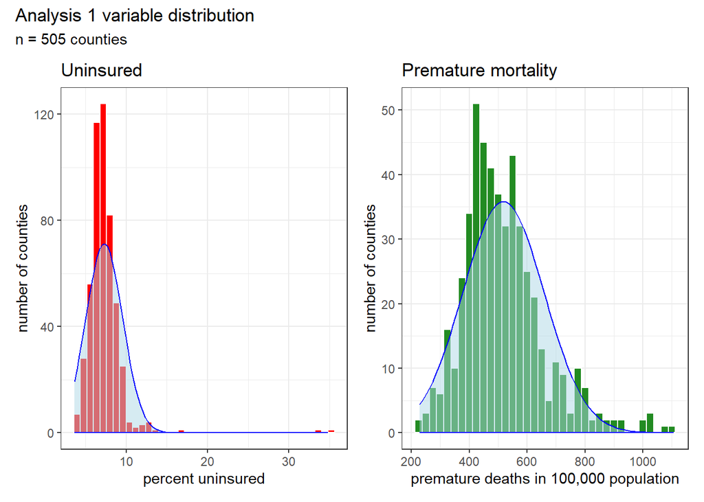

```r
bw11 = 0.8
bw12 = 25

p1 <- ggplot(a1, aes(x = uninsured)) +
  geom_histogram(binwidth = bw11, fill = "red", col = "white") +
    stat_function(fun = function(x)
    dnorm(x, mean = mean(a1$uninsured,
                         na.rm = TRUE),
          sd = sd(a1$uninsured,
                  na.rm = TRUE)) *
      length(a1$uninsured) * bw11,
    geom = "area", alpha = 0.5,
    fill = "lightblue", col = "blue"
    ) +
  labs(title = "Uninsured", y = "number of counties", x = "percent uninsured")

p2 <- ggplot(a1, aes(x = pre_mort)) +
  geom_histogram(binwidth = bw12, fill = "forestgreen", col = "white") +
      stat_function(fun = function(x)
    dnorm(x, mean = mean(a1$pre_mort,
                         na.rm = TRUE),
          sd = sd(a1$pre_mort,
                  na.rm = TRUE)) *
      length(a1$pre_mort) * bw12,
    geom = "area", alpha = 0.5,
    fill = "lightblue", col = "blue"
    ) +
  labs(title = "Premature mortality",
       x = "premature deaths in 100,000 population",
       y = "number of counties")

(p1 + p2) +
  plot_annotation(title = "Analysis 1 variable distribution",
                  subtitle = "n = 505 counties")
```

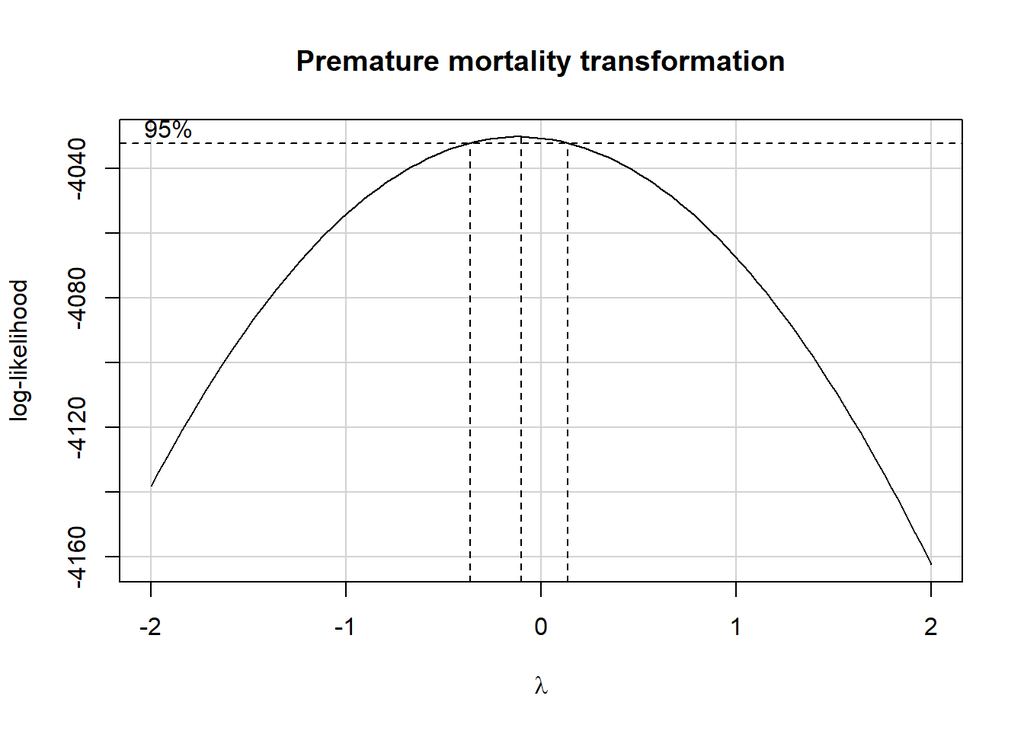

```r
fit12 <- lm(pre_mort ~ uninsured, data = a1)
boxCox(fit12, main = "Premature mortality transformation")
```

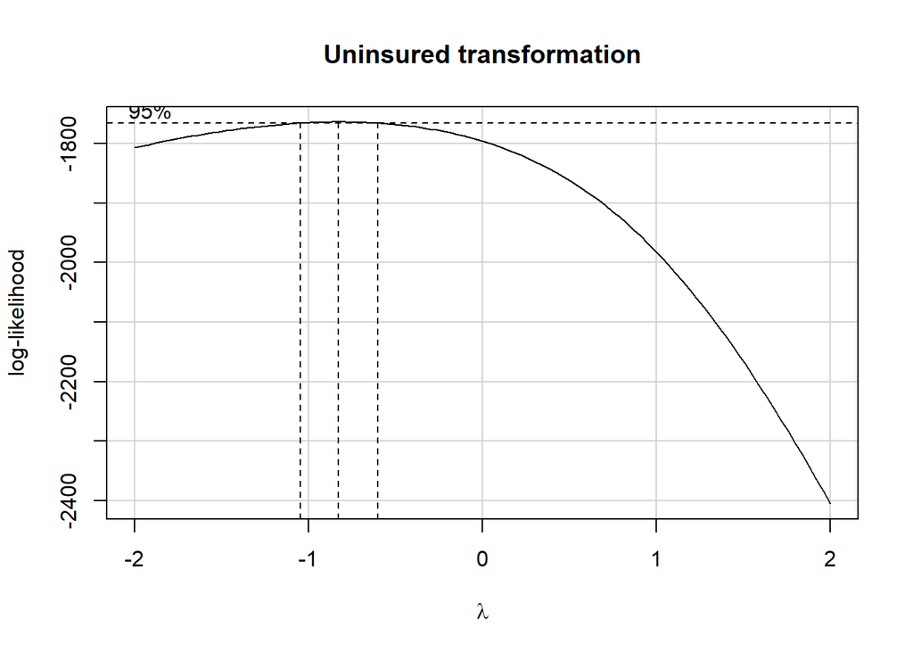

```r
fit13 <- lm(uninsured ~ pre_mort, data = a1)
boxCox(fit13, main = "Uninsured transformation")
```

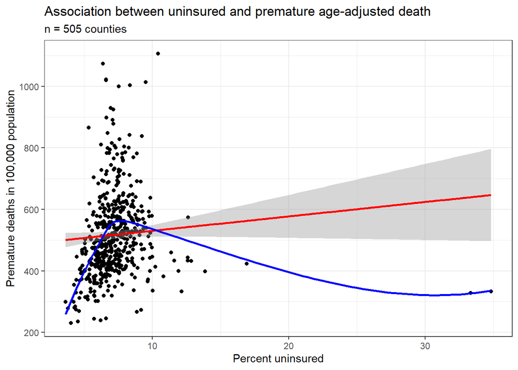

```r
ggplot(
  data = a1,
  aes(x = uninsured, y = pre_mort)
) +
  geom_point() +
  geom_smooth(method = "lm", formula = y ~ x, se = TRUE, col = "red") +
  geom_smooth(method = "loess", formula = y ~ x, se = FALSE, col = "blue") +
  labs(title = "Association between uninsured and premature age-adjusted death",
       subtitle = "n = 505 counties",
       x = "Percent uninsured", y = "Premature deaths in 100,000 population") +
  theme_bw()
```

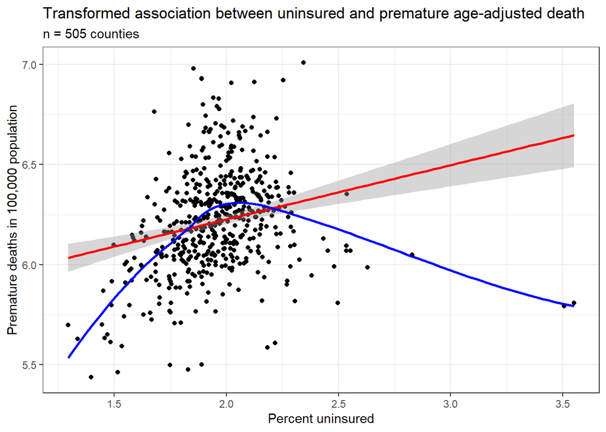

```r
ggplot(
  data = a1,
  aes(x = log(uninsured), y = log(pre_mort))
) +
  geom_point() +
  geom_smooth(method = "lm", formula = y ~ x, se = TRUE, col = "red") +
  geom_smooth(method = "loess", formula = y ~ x, se = FALSE, col = "blue") +
  labs(title = "Transformed association between uninsured and premature age-adjusted death",
       subtitle = "n = 505 counties",
       x = "Percent uninsured", y = "Premature deaths in 100,000 population") +
  theme_bw()
```

## 13.3 Approach

```r
a1 <- a1 |> mutate(pre_mort_log = log(pre_mort),
                   uninsured_log = log(uninsured))

set.seed(431)

fit1 <- stan_glm(pre_mort_log ~ uninsured_log, data = a1, refresh = 0)

model_parameters(fit1, ci = 0.90)
```

```
Parameter     | Median |       90% CI |   pd |  Rhat |  ESS |                 Prior
-----------------------------------------------------------------------------------
(Intercept)   |   5.68 | [5.52, 5.85] | 100% | 1.000 | 3861 | Normal (6.22 +- 0.65)
uninsured_log |   0.27 | [0.19, 0.35] | 100% | 1.000 | 3831 | Normal (0.00 +- 2.91)
```

```
Uncertainty intervals (equal-tailed) computed using a MCMC distribution
  approximation.
```

The prediction equation for our model is ln(y) = 0.27ln(x) + 5.68, as we used logarithm transformations on both variables.

```r
model_performance(fit1)
```

```
# Indices of model performance

ELPD    | ELPD_SE | LOOIC | LOOIC_SE | WAIC |    R2 | R2 (adj.) |  RMSE | Sigma
-------------------------------------------------------------------------------
-29.035 |  18.889 |  58.1 |   37.778 | 58.0 | 0.054 |     0.042 | 0.254 | 0.255
```

The r<sup>2</sup> value is 0.054, which is very close to zero, implying that our model is not a good fit for the data. The residual standard error is 0.255. This model was fit to n = 505 counties.

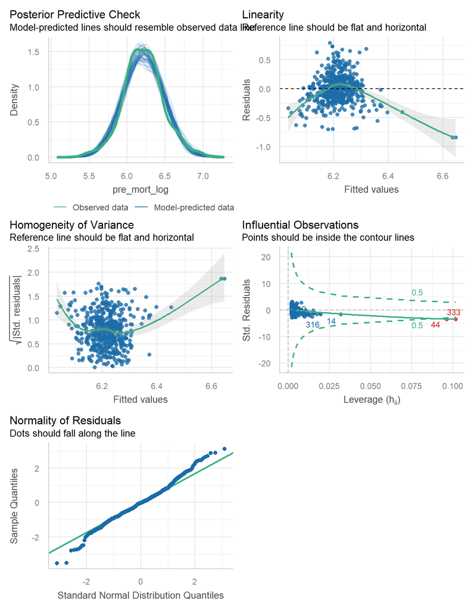

```r
check_model(fit1, detrend = FALSE)
```

```r
tab_11 <- a1 |> filter(county == 'Cuyahoga County') |>
            select(county, state, uninsured, pre_mort)

tab_12 <- a1 |> filter(county == 'Montgomery County', state == "OH") |>
            select(county, state, uninsured, pre_mort)

rbind(tab_11, tab_12) |> kable(digits = 2)
```

| county | state | uninsured | pre_mort |
| --- | --- | --- | --- |
| Cuyahoga County | OH | 7.02 | 473.32 |
| Montgomery County | OH | 7.54 | 572.87 |

```r
est_data <- tibble(uninsured_log = c(log(7.02), log(7.54)))

estimate_prediction(fit1, data = est_data, ci = 0.90) |>
  mutate(county = c("Cuyahoga County, OH", "Montgomery County, OH"),
         uninsured = exp(uninsured_log),
         predict_mort = exp(Predicted)) |>
  select(county, uninsured, predict_mort) |>
  kable(digits = 2)
```

| county | uninsured | predict_mort |
| --- | --- | --- |
| Cuyahoga County, OH | 7.02 | 498.81 |
| Montgomery County, OH | 7.54 | 508.57 |

After running some predictions using the uninsured percentage of two counties, Cuyahoga County and Montgomery County Ohio, we can see that our point estimates are quite different than the actual premature age-adjusted mortality. Cuyahoga County is over predicted by approximately 25 deaths, while Montgomery County is under predicted by approximately 64 deaths.

## 13.4 Conclusions

My research question was “How well can a linear model predict the rate of premature death in a county by the percentage of uninsured people, in 505 counties in the states of IN, KY, MI, OH, PA, and WV?” I originally believed that I think that a county with a higher percentage of uninsured people will have increased premature death. However, my investigation has led me to believe that there is essentially no correlation between the percent of population without health insurance and the premature death in that county. A linear model certainly is not appropriate for predicting the premature death using the percent uninsured in that county, for my sample. The `check_model` function supports this, as our model easily failed most of the diagnostic checks. After running some estimates on two counties in my sample, Cuyahoga County and Montgomery County Ohio, two counties I have lived in, the predictions were not close to the true number, all together showing that a linear model is not good fit for these data. While an unexciting result, it is still surprising that there is not much of a correlation at all between the percent uninsured and the premature age-adjusted death rate. Our scatter plot shows that most of the counties with high premature death actually have low percentages of uninsured people.

The biggest limitation for my analysis was simply that the data I chose are not closely associated with each other. After I made the first scatter plot, I knew that a linear model would not be appropriate for the data. Other than the presence of some outliers, the scatter plot is just a cloud without a discernible pattern. This was only confirmed the more tests I ran. The model failed almost all of the `check_model` tests, including some of the most important tests for a linear model, the linearity and homogeneity of variance checks. I cannot say my model is a good fit for my sample, so I would definitely not apply it to any populations, but I would be interested to see if including other states might create more of a pattern. All of the states I choose are fairly rural, often with a few bigger cities, so to continue further analysis I would be interested in bringing in states that are more urban populations or even more rural than the states I choose. I would also be interested in investigating some of the demographic information about the counties to see if maybe there is a confounding factor at play. I would look at some of the demographic information about the counties that were outliers and some that had high premature death and low uninsured percents and see if there was anything that made them similar in other ways.

# 14 Analysis 2: Comparing Two Independent Samples

## 14.1 Variables

Our predictor for analysis 2 is rural population grouped, a measure of the percent of population living in a census-defined rural area divided into two groups. The low group contains counties with less than 55% of the population living in rural areas, while the high group has counties with greater than 74% of the population living in rural areas. The outcome is the percentage of adults reporting fair or poor health, age-adjusted. This sample includes CHR 2025 data from 400 counties in 6 states: Indiana, Kentucky, Michigan, Ohio, Pennsylvania, and West Virginia. We are not missing any values for the `poor_health` variable as shown in section 10.2’s `describe_distribution()` results. The `rural_grp` variable is missing data as demonstrated in section 10.3’s `data_codebook` results, but this is expected from how the variable was constructed.

```r
chr_2025 |> filter(county == 'Cuyahoga County') |>
            select(rural_grp, poor_health) |> kable(digits = 2, align = "c")
```

| rural_grp | poor_health |
| --- | --- |
| Low | 19.5 |

Cuyahoga County, OH is in the low rural group and 19.5% of the adult population report poor health.

## 14.2 Summaries

```r
a2 <- chr_2025 |> select(poor_health, prop_rural, rural_grp, state, county, fipscode) |>
                  filter(complete.cases(rural_grp))

a2 |> group_by(rural_grp) |> reframe(lovedist(poor_health)) |> kable(digits = 2)
```

| rural_grp | n | miss | mean | sd | med | mad | min | q25 | q75 | max |
| --- | --- | --- | --- | --- | --- | --- | --- | --- | --- | --- |
| High | 201 | 0 | 22.16 | 4.52 | 21.6 | 4.60 | 11 | 18.6 | 25.1 | 35.5 |
| Low | 199 | 0 | 18.53 | 3.02 | 18.7 | 2.97 | 11 | 16.5 | 20.6 | 25.7 |

At first glance everything looks okay here, there does seem to be some differences in the means of the groups so there might be something going on. It also looks like the variances are pretty different from each other, which might be important for our analysis.

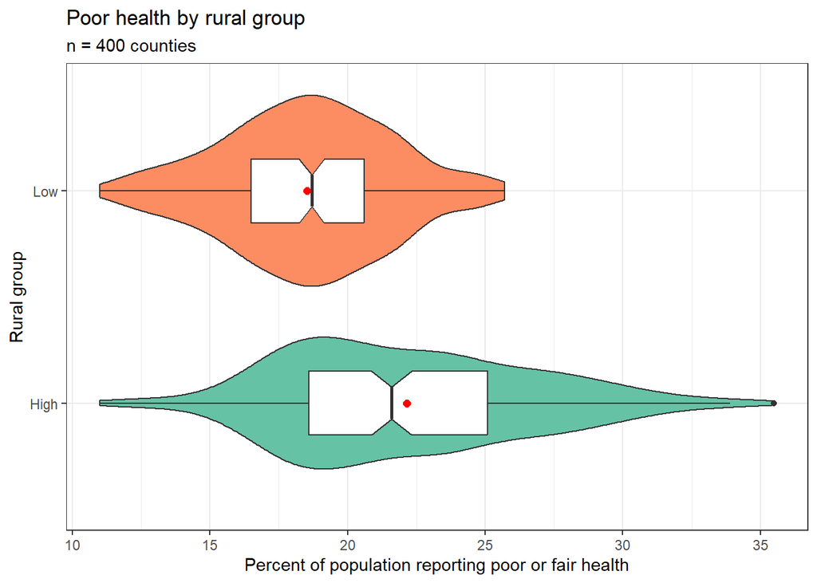

```r
ggplot(a2, aes(y = rural_grp, x = poor_health, fill = rural_grp)) +
  geom_violin() +
  geom_boxplot(width = 0.3, fill = "white", notch = TRUE) +
  stat_summary(fun = mean, geom = "point", size = 2, col = "red") +
  scale_fill_brewer(palette = "Set2") +
  guides(fill = "none") +
  labs(title = "Poor health by rural group",
       subtitle = "n = 400 counties",
       x = "Percent of population reporting poor or fair health",
       y = "Rural group")
```

Our distributions of both variables look good, with only one outlier. The low group looks like it has a pretty normal distribution, while the high group is more stretched out and might be heavy tailed. It looks like there might be some right skew in the high group too, as the mean is pulled to the right of the median.

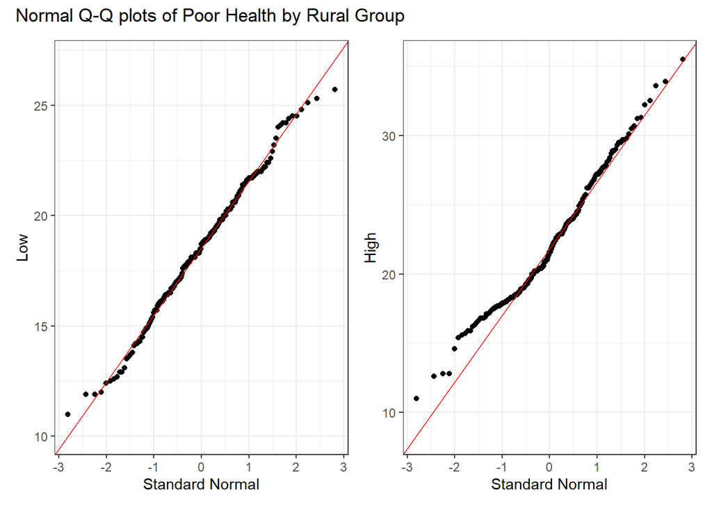

```r
p21 <- a2 |>
  filter(rural_grp == "Low") |>
  ggplot(aes(sample = poor_health)) +
  geom_qq() +
  geom_qq_line(col = "red") +
  labs(y = "Low", x = "Standard Normal")

p22 <- a2 |>
  filter(rural_grp == "High") |>
  ggplot(aes(sample = poor_health)) +
  geom_qq() +
  geom_qq_line(col = "red") +
  labs(y = "High", x = "Standard Normal")

p21 + p22 +
  plot_annotation(title = "Normal Q-Q plots of Poor Health by Rural Group")
```

This seems to confirm what we were seeing in the box plots, with the low group following the normal distribution pretty well, while the high group seems to have some right skew and more problems with normality.

## 14.3 Approach

```r
m2 <- t.test(poor_health ~ rural_grp, conf.level = 0.90,
              var.equal = TRUE, data = a2)

model_parameters(m2, ci = 0.90)
```

```
Two Sample t-test

Parameter   |     Group | rural_grp = High | rural_grp = Low | Difference
-------------------------------------------------------------------------
poor_health | rural_grp |            22.16 |           18.53 |       3.63

Parameter   |       90% CI | t(398) |      p
--------------------------------------------
poor_health | [2.99, 4.26] |   9.43 | < .001

Alternative hypothesis: true difference in means between group High and group Low is not equal to 0
```

```r
set.seed(4312)

boot.t.test(poor_health ~ rural_grp, data = a2, R = 2000,
            var.equal = FALSE, conf.level = 0.90)
```

```
    Bootstrap Welch Two Sample t-test

data:  poor_health by rural_grp
number of bootstrap samples:  2000
bootstrap p-value < 5e-04
bootstrap difference of means (SE) = 3.62705 (0.38258)
90 percent bootstrap percentile confidence interval:
 3.010023 4.258747

Results without bootstrap:
t = 9.4457, df = 349.2, p-value < 2.2e-16
alternative hypothesis: true difference in means is not equal to 0
90 percent confidence interval:
 2.994997 4.262095
sample estimates:
mean in group High  mean in group Low
          22.15970           18.53116
```

| Model | Difference | 90% Confidence Interval |
| --- | --- | --- |
| **pooled t** | 3.63 | (2.99, 4.26) |
| **bootstrap** | 3.63 | (3.01, 4.25) |

Our difference in means between groups is essentially the same using both a pooled t procedure and a bootstrap procedure, and very similar confidence intervals. I think the bootstrap is more appropriate here because one of our populations is not described that well by a normal distribution and the variances between groups are pretty different, so we can use a bootstrap model without pooling, as we did here.

## 14.4 Conclusions

A limitation is that my sample of states is not representative of the entire United States. I think you could argue that it might be representative of the Midwest, but there are states that are a part of the sample that are not in the Midwest. The first thing I would do for further analysis is to bring in more states, perhaps taking a random sample of counties from every state to compare. I would also change the groups, perhaps researching some established guidelines on what percentages would be good cutoff points for a rural and non-rural county to make the results more useful. While having similar sized groups is nice for analysis, I think that it was not a good choice for creating a useful result with the data I chose. I think these changes might result in finding a meaningful difference between the reported health in rural and non-rural counties that could be used to research why that health disparity might exist.

# 15 Analysis 3: Comparing an Outcome in CHR 2025 to its value in CHR 2019

## 15.1 Variables

Our variables for analysis 3 are the average number of mentally unhealthy days reported in past 30 days, age-adjusted, from the 2019 CHR and 2025 CHR, recorded in 2016 and 2022 respectively. This sample includes data from 505 counties in 6 states: Indiana, Kentucky, Michigan, Ohio, Pennsylvania, and West Virginia. We are not missing any values for these variables as shown in section 10.2’s `describe_distribution()` results.

## 15.2 Summaries

```r
a3 <- chr_2025 |> mutate(diff_mental = mental_2025 - mental_2019) |>
                  select(fipscode, state, county, mental_2025, mental_2019, diff_mental)

a3 |> reframe(lovedist(diff_mental)) |> kable(digits = 2)
```

| n | miss | mean | sd | med | mad | min | q25 | q75 | max |
| --- | --- | --- | --- | --- | --- | --- | --- | --- | --- |
| 505 | 0 | 1.62 | 0.45 | 1.65 | 0.46 | 0.54 | 1.3 | 1.91 | 2.71 |

Everything looks okay with the difference between 2025 and 2019 at first glance, the mean and median are very close, so it doesn’t look like we will have much skew.

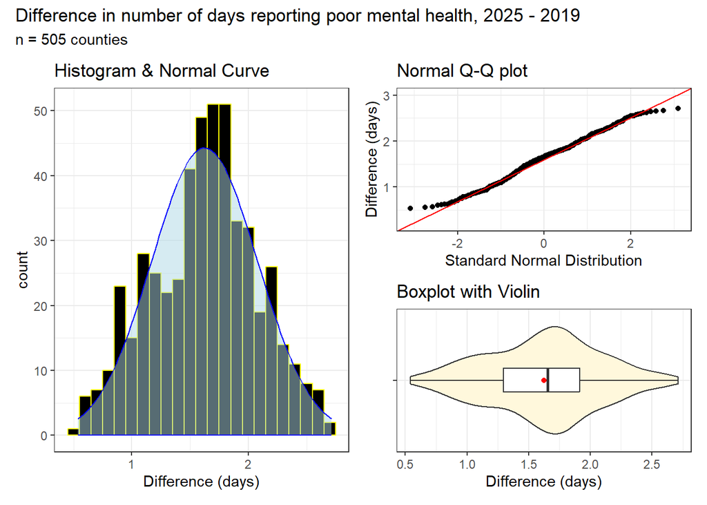

```r
bw3 = 0.1

p1_3 <- ggplot(a3, aes(x = diff_mental)) +
  geom_histogram(binwidth = bw3,
                 fill = "black", col = "yellow") +
  stat_function(fun = function(x)
    dnorm(x, mean = mean(a3$diff_mental,
                         na.rm = TRUE),
          sd = sd(a3$diff_mental,
                  na.rm = TRUE)) *
      length(a3$diff_mental) * bw3,
    geom = "area", alpha = 0.5,
    fill = "lightblue", col = "blue"
    ) +
  labs(
    x = "Difference (days)",
    y = "count",
    title = "Histogram & Normal Curve"
  ) +
  theme_bw()

p2_3 <- ggplot(a3, aes(sample = diff_mental)) +
  geom_qq() +
  geom_qq_line(col = "red") +
  labs(
    y = "Difference (days)",
    x = "Standard Normal Distribution",
    title = "Normal Q-Q plot"
  ) +
  theme_bw()

p3_3 <- ggplot(a3, aes(x = diff_mental, y = "")) +
  geom_violin(fill = "cornsilk") +
  geom_boxplot(width = 0.2) +
  stat_summary(
    fun = mean, geom = "point",
    shape = 16, col = "red"
  ) +
  labs(
    y = "", x = "Difference (days)",
    title = "Boxplot with Violin"
  ) +
  theme_bw()

p1_3 + (p2_3 / p3_3) +
  plot_annotation(
    title = "Difference in number of days reporting poor mental health, 2025 - 2019",
    subtitle = "n = 505 counties"
  )
```

We appear to have a fairly normal distribution, the tails are a little light, but there are no significant outliers or problems with normality.

```r
r3 <- cor_test(a3, "mental_2025", "mental_2019")

r3
```

```
Parameter1  |  Parameter2 |    r |       95% CI | t(503) |         p
--------------------------------------------------------------------
mental_2025 | mental_2019 | 0.58 | [0.52, 0.64] |  16.01 | < .001***

Observations: 505
```

Our pearson correlation is 0.58, indicating that there seems to be a mild positive correlation between the number of poor mental health days in 2019 and 2025.

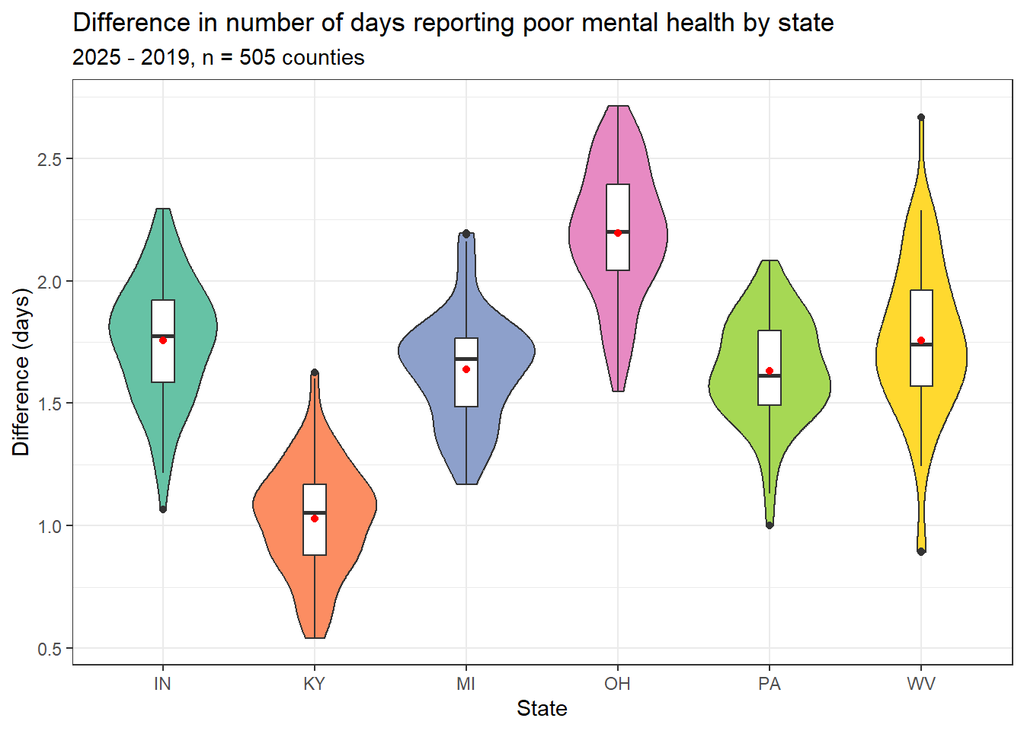

```r
ggplot(a3, aes(x = state, y = diff_mental)) +
  geom_violin(aes(fill = state)) +
  geom_boxplot(width = 0.15) +
  stat_summary(geom = "point", fun = "mean", col = "red") +
  scale_fill_brewer(palette = "Set2") +
  guides(fill = "none") +
  labs(title = "Difference in number of days reporting poor mental health by state",
       subtitle = "2025 - 2019, n = 505 counties",
       x = "State",
       y = "Difference (days)")
```

To answer my research question I also wanted to look at the distribution by state. We can see a few outliers in every state but Ohio, but none appear to have terrible issues with normality. It looks like Ohio counties had slightly higher mean differences, while Kentucky counties had slightly lower mean differences than the rest which are all very similar.

```r
fit_state <- lm(diff_mental ~ state, data = a3)

means_state <- estimate_means(fit_state, ci = 0.90)
```

```
We selected `by=c("state")`.
```

```r
means_state
```

```
Estimated Marginal Means

state | Mean |   SE |       90% CI | t(499)
-------------------------------------------
IN    | 1.76 | 0.03 | [1.71, 1.80] |  67.81
KY    | 1.03 | 0.02 | [0.99, 1.07] |  45.40
MI    | 1.64 | 0.03 | [1.59, 1.68] |  60.09
OH    | 2.19 | 0.03 | [2.15, 2.24] |  82.82
PA    | 1.63 | 0.03 | [1.58, 1.68] |  53.77
WV    | 1.75 | 0.03 | [1.70, 1.81] |  52.38

Variable predicted: diff_mental
Predictors modulated: state
```

Here we have the estimated mean difference by state and can again see that Ohio and Kentucky stand out, but the rest are pretty similar.

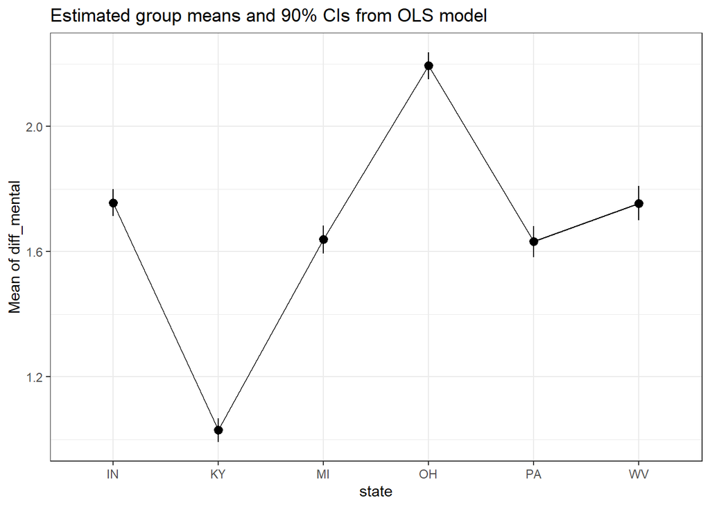

```r
plot(visualisation_recipe(means_state)) +
  labs(title = "Estimated group means and 90% CIs from OLS model")
```

Plotting the means and the 90% confidence intervals we can see that Michigan and Pennsylvania’s confidence intervals significantly overlap, as well as Indiana and West Virginia, and that these four are all fairly close to each other. Ohio and Kentucky seem to be different from all other groups.

## 15.3 Approach

```r
fit_diff <- lm(diff_mental ~ 1, data = a3)

fit_diff |> model_parameters(ci = 0.90) |> kable(digits = 2)
```

| Parameter | Coefficient | SE | CI | CI_low | CI_high | t | df_error | p |
| --- | --- | --- | --- | --- | --- | --- | --- | --- |
| (Intercept) | 1.62 | 0.02 | 0.9 | 1.59 | 1.66 | 80.21 | 504 | 0 |

```r
set.seed(4313)

fit_boot <- t.test(a3$diff_mental, conf.level = 0.90)

model_parameters(fit_boot, ci = 0.90)
```

```
One Sample t-test

Parameter   | Mean | mu | Difference |       90% CI | t(504) |      p
---------------------------------------------------------------------
diff_mental | 1.62 |  0 |       1.62 | [1.59, 1.66] |  80.21 | < .001

Alternative hypothesis: true mean is not equal to 0
```

[output not shown]

```r
con3 <- estimate_contrasts(fit_state, contrast = "state",
                            ci = 0.90, p.adjust = "holm")

con3
```

```
Marginal Contrasts Analysis

Level1 | Level2 | Difference |   SE |         90% CI | t(499) |      p
----------------------------------------------------------------------
KY     | IN     |      -0.73 | 0.03 | [-0.78, -0.67] | -21.11 | < .001
MI     | IN     |      -0.12 | 0.04 | [-0.18, -0.06] |  -3.14 |  0.002
OH     | IN     |       0.44 | 0.04 | [ 0.38,  0.50] |  11.80 | < .001
PA     | IN     |      -0.12 | 0.04 | [-0.19, -0.06] |  -3.12 |  0.002
WV     | IN     |  -1.69e-03 | 0.04 | [-0.07,  0.07] |  -0.04 |  0.968
MI     | KY     |       0.61 | 0.04 | [ 0.55,  0.67] |  17.17 | < .001
OH     | KY     |       1.16 | 0.03 | [ 1.11,  1.22] |  33.38 | < .001
PA     | KY     |       0.60 | 0.04 | [ 0.54,  0.66] |  15.90 | < .001
WV     | KY     |       0.73 | 0.04 | [ 0.66,  0.79] |  17.93 | < .001
OH     | MI     |       0.55 | 0.04 | [ 0.49,  0.62] |  14.60 | < .001
PA     | MI     |  -6.63e-03 | 0.04 | [-0.07,  0.06] |  -0.16 |  0.871
WV     | MI     |       0.12 | 0.04 | [ 0.05,  0.19] |   2.69 |  0.007
PA     | OH     |      -0.56 | 0.04 | [-0.63, -0.50] | -13.94 | < .001
WV     | OH     |      -0.44 | 0.04 | [-0.51, -0.37] | -10.27 | < .001
WV     | PA     |       0.12 | 0.05 | [ 0.05,  0.20] |   2.72 |  0.007

Variable predicted: diff_mental
Predictors contrasted: state
p-values are uncorrected.
```

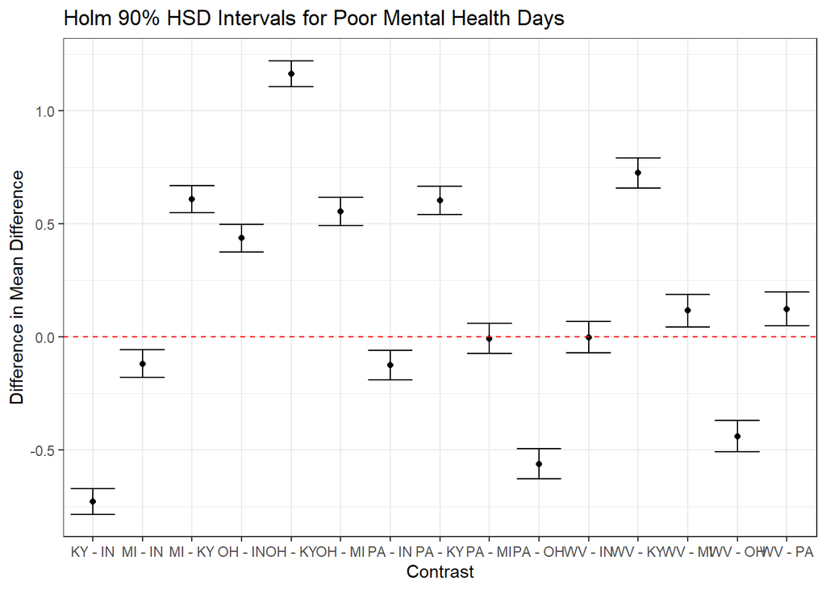

```r
con3_tib <- tibble(con3) |>
  mutate(contr = str_c(Level1, " - ", Level2))

ggplot(con3_tib, aes(x = contr, y = Difference)) +
  geom_point() +
  geom_errorbar(aes(ymin = CI_low, ymax = CI_high)) +
  geom_hline(yintercept = 0, col = "red", lty = "dashed") +
  labs(title = "Holm 90% HSD Intervals for Poor Mental Health Days",
       x = "Contrast",
       y = "Difference in Mean Difference")
```

## 15.4 Conclusions

My research question for analysis three was “Does the difference in poor mental health days from 2025 to 2019 vary by state, in 505 counties in the states of IN, KY, MI, OH, PA, and WV?” I believed that all the states would have increased poor mental health days from 2019 to 2025, but I was initially unsure if there would be many differences between the states. After performing the analysis, it looks like there is a difference in the mean difference between 2025 and 2019 between most of the states, except for the pair of West Virginia and Indiana and the pair of Pennsylvania and Michigan. However, these differences are minimal when looking at the overall scope of what they mean. The biggest difference is only estimated to be 1.16 days difference in mean difference. I do not think that this difference would mean much clinically. I think the more helpful visualization is the plot of the mean differences and their confidence intervals, because you can see that there is something going on with Ohio and Kentucky having pretty different means from the rest. The mean difference in poor mental health days across all the counties in my sample was 1.62, with a 90% confidence interval of 1.59 to 1.66. This means we can say with 90% confidence that the true mean difference in the number of poor mental health days from 2025 to 2019 in our sample is between 1.59 and 1.66 days. This is a pretty narrow confidence interval, showing that there is not much variation in the mean difference between the states. I did predict one thing correctly, however, that there was an increase in poor mental health days across the board, with the minimum difference of 2025 - 2019 being greater than zero, so no county had decreased poor mental health days from 2019 to 2025.

I think my greatest limitation was in my research question. I think there is an interesting correlation to study in why poor mental health days have increased in very county in our sample from 2019 - 2025, but since my research question focused on looking at the variation by state, my results ended up being less interesting when there wasn’t much there. I would direct further study to look at why Ohio had a greater increase in mean poor mental health days from 2019 to 2025, and why Kentucky had less. There approximately a day of difference between the states’ mean differences, so I would want to investigate what factors might have led Ohio to have a greater increase from 2019 to 2025 than Kentucky. I would additionally choose a broader variety of states outside of the region I chose, to see if my results could apply to the entire United States, because as it stands I do not believe my sample is representative of the entire US because it is only one geographical region.

# 16 Portfolio Reflections

I think the most important thing I learned in working on this project is the workflow involved in doing statistical analysis. While we usually see the full process in class, from data management to creating graphs and models, I feel like the labs had us doing bits and pieces of this. I really felt like I was able to think through the process of starting from summaries of the data, to visualizing and asking questions, and creating models, then presenting the analysis in the video. I felt this especially on analysis three, as my research question required that I make more graphs and models than just those asked for in the instructions, and I felt very confident working through the analysis after having done the other two analyses. It feels like I would be capable of doing analysis on my own without the guidance of the class and it’s an exciting feeling! I could easily see myself needing to work through similar analysis in my future career, so that I am already feeling confident is great.

# 17 AI Usage

In preparing this response, I made no use of AI outside of spell-check and code completion within RStudio.